# JIRN Session 5: Controlling Data Access

Robert Ashmead

## Last Session

1. How can other people see my R-Shiny apps (hosting)
2. Accessibility Resources and Tips
3. Dynamic UI elements

## Take Home Activity

1. In our dashboard’s map we limit ourselves to analyizing information about the levels of PROS_DEGREE. Use a dynamic UI selection to first select a variable to analyze, then a single level for that variable to map.

## Change the map variable selection

- change the first dropdown to be the standard outcome_variables
- add a `uiOutput` for our dynamic dropdown that we will make in the server

```r
selectInput(
    inputId = "selected_outcome_map",
    label = "Choose a Variable to Map",
    choices = outcome_variables,
    selected = outcome_variables[1],
    multiple = FALSE
),

uiOutput("map_var_level_selection"),
```

## Add a renderUI to the server

```r
output$map_var_level_selection = renderUI({

    #get the levels of the selected variable
    var_level = arrest_data %>%
        filter(ARREST_DATE >= input$daterange_map[1] & ARREST_DATE <= input$daterange_map[2]) %>%
        distinct(.data[[input$selected_outcome_map]]) %>%
        arrange()

    selectInput(
        inputId = "selected_outcome_level_map",
        label = "Choose a Level Within the Variable to Map",
        choices = var_level,
        selected = var_level[1],
        multiple = FALSE
    )
})
```

## Simplify our map_data calculation

```r
map_data = reactive({

    all_outcomes = arrest_data %>%
        filter(ARREST_DATE >= input$daterange_map[1] & ARREST_DATE <= input$daterange_map[2]) %>%
        group_by(COUNTY) %>%
        summarize(count_var = sum(.data[[input$selected_outcome_map]] %in% input$selected_outcome_level_map,na.rm = TRUE))

    out  = fl_counties_geo %>%
            left_join(all_outcomes, by = c(NAMELSAD = "COUNTY")) %>%
            mutate("count_var_rate_per_10k"= count_var / (POPESTIMATE/10000))

    return(out)
})
```

## Adjust the renderLeaflet to reflect the changes

- only minor changes are needed here

```r
output$output_map = renderLeaflet({

    req(input$selected_outcome_level_map)
    input$update_button_map

    isolate({

        std_option_var_text = ifelse(input$stand_map_pop, "_rate_per_10k", "")
        select_var_name = paste0("count_var",std_option_var_text)

        std_legend_var_text = ifelse(input$stand_map_pop, "<br>Per 10k Persons", "")
        legend_title = paste0( input$selected_outcome_level_map, std_legend_var_text)

        colors_for_palette = c("#EBF6FF","#6BAED6", "#08306B")
        cont_pal = colorNumeric(colors_for_palette, domain = map_data()[[select_var_name]], na.color = "#f1f1e0")

        map_continous_scale = leaflet() %>%
        addProviderTiles(providers$Esri.WorldGrayCanvas) %>% #this is a more plain tile layer
        addPolygons(data =  map_data(),
                    color = "black", #controls the color of the shape boundaries
                    weight = 2, #conrtrols the thickness of the shape boundaries
                    fillOpacity = 1, #controls the opacity of the fill color
                    fillColor = cont_pal(map_data()[[select_var_name]]),
                    label = ~NAMELSAD) %>% #label gives the tooltip/hover label
        addLegend("bottomright",
                    pal = cont_pal,
                    title = legend_title,
                    values = map_data()[[select_var_name]],
                    na.label = paste("No Estimate Available"),
                    opacity = 1)
    })
})
```

## Questions?

## Final Assignment Reminder

- Practice your R-Shiny skills and understanding
- Receive a certificate from JIRN
- NIJ’s Recidivism Challenge Full Dataset
- Due by 4/5/2025
- See HTML on the github page

## Today’s Agenda

1. Authentication methods
2. Including suppression rules in your output
3. Best practices for creating dashboards datasets with sensitive data

## Authentication

- Let’s assume we have figured out a way to host our dashboard already
- If I don’t want **everyone** to be able to see/utilize it, how can we accomplish that?

## Common Use Cases

1. Only allow a certain group of users to see/utilize the dashboard
   - Sensitive or restricted data
   - “Dev” version of the dashboard before larger public release
   - “Internal” company resource
2. Allow different users access to different data or features within the dashboard
   - Different levels of user access

## Options available through hosting solutions

1. [Posit Connect](https://posit.co/products/enterprise/connect/)
- Specifically uses a user-account model for access management
  - Keep content private (only visible to the developer)
  - Share content with individuals or groups
  - Make content visible to everyone with server access
- The number of licenses (users) is tied to the cost

## Posit Connect Access Panel

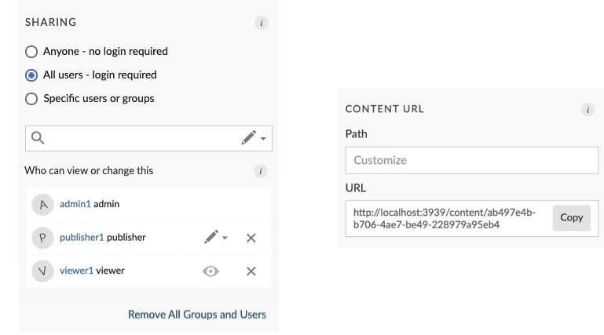

From https://docs.posit.co/connect/user/content-settings/

## Options available through hosting solutions

2. [shinyproxy](https://www.shinyproxy.io)
- Authentication Options
  - Multiple ways for authentication that is connected to other services (e.g. LDAP, OpenID, and SAML protocols)
  - Web Service Based Authentication
  - Simple authentication (plain text list of users and passwords)
- See [link](https://www.shinyproxy.io/documentation/configuration/#authentication) for more information
- Possible to have the user id as an environment variable to be used within your dashboard

## Options available through hosting solutions

3. Host on a server that is only reachable for users at your company or on your network
- Special use case if you wanted the dashboards to be only accessible to your company/network
- Could work with several of the hosting solutions

## Options to build authentication into your Shiny App

**Disclaimer**: I am not a IT security expert. Check with your IT department to ensure that they are comfortable with these options if you are planning on implmenting them in practice.

**Note**: Building authentication into your Shiny App may not align with your license agreement for Posit Connect.

1. [shinyauthr R package](https://github.com/PaulC91/shinyauthr)
2. [shinymanger R package](https://datastorm-open.github.io/shinymanager/)
3. [Google Firebase](https://firebase.google.com/) and [firebase R package](https://github.com/JohnCoene/firebase)

## Shinyauthr

- Create and manage your own username and password list
- Good solution if you just need a single username/password for a “dev” version

```r
#if you haven't installed shinyauthr yet
install.packages(shinyauthr)
```

## Shinyauthr Step 1 - Create and Hash Usernames/Passwords

- Create a CSV or XLSX file with a column for usernames and one for passwords
- This should be in a directory that is not transfered with the dashboard code to the server

```
user_base.csv
```

```
"user","password"
"user1","pass1"
"user2","pass2"
"user3","pass3"
```

- Create an R script **outside** of the dashboard files to read in the plain text passwords and hash them
- Save the output as and .rds or .RData file

```
create_hashed_passwords.R
```

```r
library(here)
library(sodium)

#read in the data from the csv file
user_base = read.csv(here("session5", "examples", "example1_shinyauthr","create_passwords","user_base.csv"))

#hash the passwords
user_base$password = do.call(c,lapply(user_base$password, FUN = sodium::password_store))

#save the hashed version to an RDS file
saveRDS(user_base,  here("session5", "examples", "example1_shinyauthr","create_passwords","user_base.rds") )
```

## Shinyauthr Step 2 - Load the hashed user passwords into global

- Add a line in `global.R` to load the .rds file we just created
- We’ll call that object `user_base`

```r
user_base = readRDS(here("session5", "examples", "example1_shinyauthr","create_passwords","user_base.rds"))
```

## Shinyauthr Step 3 - Adjust the UI so that there is only a login page

- Use the standard functions from shinyauthr and create login page
- Note that we added an `id` parameter to the navbarPage that we will use to reference it

```
ui.R
```

```r
navbarPage(title = "Florida Arrests",
           theme = shinythemes::shinytheme("cosmo"),
           lang = "en-US",
           id = "navbar",

   tabPanel("Login",
            # add logout button UI
            div(class = "pull-right", shinyauthr::logoutUI(id = "logout")),
            # add login panel UI function
            shinyauthr::loginUI(id = "login")
   )
)
```

## Shinyauthr Step 4 - Create the other UI content as seperate R objects

- We’ve removed the other previous UI information from the ui.R file.
- There are several ways to do this, but I have put that code in a seperate file called `ui_tabs.R`
- I’ve adjusted it to make the different tabs seperate R objects called `welcome_tab`, `data_analysis_tab`, and `map_tab`.
- Otherwise this is the exact same code as before

```
ui_tabs.R
```

```r
welcome_tab = tabPanel("Welcome",
         tags$h1("Welcome to the Florida Arrests Analysis Dashboard"),
         "The data in this dashboard comes from ",
         tags$a("the Florida Department of Law Enforcement Website", target = "_blank",
                style = "color: #0000C2;",
                href = "https://www.fdle.state.fl.us/CJAB/FSAC/CJDT-Presentation.aspx")
)

data_analysis_tab = tabPanel("Data Analysis",
  fluidRow(
    sidebarPanel(
        dateRangeInput(
            "daterange",
            "Select a Date Range Input for the Arrest Date",
            start = "2014-01-01", #initial value
            end = "2018-12-31", #initial value
            min = "2014-01-01", #minimum allowed date
            max = "2018-12-31", #maximum allowed date
            format = "yyyy-mm-dd"
        ),
        selectInput(
            inputId = "selected_outcome",
            label = "Choose a Variable to Analyze",
            choices = outcome_variables,
            selected = outcome_variables[3],
            multiple = FALSE
        ),
        selectInput(
            inputId = "selected_grouping",
            label = "(Optional) Choose a variable to group the anlaysis by",
            choices = grouping_variables,
            selected = "no_grouping",
            multiple = FALSE
        ),
        checkboxInput(
            inputId = "add_percent_column",
            label ="Show Percent (within group)",
            value = FALSE
        ),
        checkboxInput(
            inputId = "remove_missing",
            label ="Remove Missing Values from Calculations",
            value = FALSE
        ),
        actionButton(
            inputId = "update_button",
            label = "Update the Plot and Table"
        )
    ),
    mainPanel(
       plotlyOutput("output_plot")
    )
  ), #end fluidrow
  fluidRow(
      column(12, align="center",
             DTOutput("output_table")
      )
  )
)#end tabPanel

map_tab = tabPanel("Map",
         fluidRow(
             sidebarPanel(
                 dateRangeInput(
                     inputId = "daterange_map",
                     label = "Select a Date Range Input for the Arrest Date",
                     start = "2014-01-01", #initial value
                     end = "2018-12-31", #initial value
                     min = "2014-01-01", #minimum allowed date
                     max = "2018-12-31", #maximum allowed date
                     format = "yyyy-mm-dd"
                 ),
                 selectInput(
                     inputId = "selected_outcome_map",
                     label = "Choose a Variable to Map",
                     choices = outcome_variables,
                     selected = outcome_variables[1],
                     multiple = FALSE
                 ),

                 uiOutput("map_var_level_selection"),

                 checkboxInput(
                     inputId = "stand_map_pop",
                     label ="Standardize by county population",
                     value = TRUE
                 ),
                 actionButton(
                     inputId = "update_button_map",
                     label = "Update the Map"
                 )
             ),
             mainPanel(
                 leafletOutput("output_map")
             )
         ) #end fluidrow
)#end tabPanel
```

## Shinyauthr Step 5 - Load the ui_tabs.R objects in global

- Add a line in `global.R` to source `ui_tabs.R`
- Note in our case this must go after we have defined `outcome_variables`, `grouping_variables`, etc. because those objects are referenced in `ui_tabs.R`

```r
source(here("session5", "examples", "example1_shinyauthr","ui_tabs.R"))
```

## Shinyauthr Step 6 - Server Updates

- Add the credentials and login information
- `observeEvent` is a way to perform an action in response to an event in Shiny
- If the credential information changes and the user is authorized, the login tab is removed and we create our other UI tabs
- Move the previous server code within the `if(credentials()$user_auth)` statement to help gurantee server objects are not built before login

```
server.R
```

```r
function(input, output){

    credentials <- shinyauthr::loginServer(
        id = "login",
        data = user_base,
        user_col = user,
        pwd_col = password,
        sodium_hashed = TRUE,
        log_out = reactive(logout_init())
    )

    # call the logout module with reactive trigger to hide/show
    logout_init <- shinyauthr::logoutServer(
        id = "logout",
        active = reactive(credentials()$user_auth)
    )

    observeEvent(credentials()$user_auth, {
        # if user logs in successfully
        if(credentials()$user_auth) {
            removeTab("navbar", "Login")

            appendTab("navbar", welcome_tab, select = TRUE)
            appendTab("navbar", data_analysis_tab)
            appendTab("navbar", map_tab)

            tab_data = reactive({
                if(input$selected_grouping != "no_grouping"){

            #the rest of our previous server code is the same
            #it is just moved within the if(credentials()$user_auth) statement
    ...
```

## Other ways to use shinyauthr

- Single username/password for simple protection
- Map the usernames to access groups and subset the accessible data based on those access groups
  - username can be seen as part of `credentials()`

## shinymanger and firebase

- [shinymanager demo](https://dreamrs.shinyapps.io/shinymanager-demo/)
  - username/passwords 1. shiny 2.shinymanager
- Both have their own syntax for setting up the login and credentials
- But the other portion of the shiny code will look similar
  - Setup initial UI with just the login information
  - Once the user logs in successfully, add the other UI tabs
- Shinymanager allows for updating users and passwords in the app so the setup for a server may be more complicated to store and update the database of usernames and passwords.

# Suppression Rules

## Common Suppression Rule Use Cases

1. If the sample size for an estimate/tabulation is too small
2. If the coefficent of variation (CV) is too large for an estimate
3. Minimum sample size for levels of variables within regression models
- Suppression can be at the cell level (in the case of a larger cross-tabulation)
- Or for the whole analysis

## How can we implement these kinds of rules in our apps?

1. Write analysis code and suppression logic as a function
   - Allows for testing cases outside of the app
   - Easier to confirm it works as intended
2. If you are supressing output based on givenrules, make sure that happens in the **server**
   - It is possible to show/hide UI elements based on logic (we haven’t discussed it), but this is a bad approach becuase a knowledgeable user can unhide UI elements in the HTML webpage in some cases.

## Suppression logic as a function

- Let’s add a rule to our analysis that suppresses any counts less than 10.
- First let’s turn our `tab_data` calculation into a function
  - identify the function parameters (inputs)

```r
tab_data = reactive({
    if(input$selected_grouping != "no_grouping"){

        out = arrest_data %>%
            filter(ARREST_DATE >= input$daterange[1] & ARREST_DATE <= input$daterange[2]) %>%
            group_by( .data[[input$selected_outcome]], .data[[input$selected_grouping]] ) %>%
            summarize(count = n())
    }else{

        out = arrest_data %>%
            filter(ARREST_DATE >= input$daterange[1] & ARREST_DATE <= input$daterange[2]) %>%
            group_by( .data[[input$selected_outcome]] ) %>%
            summarize(count = n()) %>%
            arrange(desc(count))
    }

    if(input$remove_missing){

        out = out %>% filter(! is.na(.data[[input$selected_outcome]]))
    }

    if(input$add_percent_column){

        if(input$selected_grouping != "no_grouping"){

            out = out %>%
                group_by(.data[[input$selected_grouping]]) %>%
                mutate(percent = 100*round(count/sum(count),4))

        }else{
            out = out %>%
                mutate(percent = 100*round(count/sum(count),4))
        }
    }
    return(out)
})
```

## Suppression logic as a function

- New function (no supression rule yet)!

```r
createTabData = function(arrest_data, selected_grouping, selected_outcome, daterange,
                         remove_missing = FALSE, add_percent_column = FALSE){

    if(selected_grouping != "no_grouping"){

        out = arrest_data %>%
            filter(ARREST_DATE >= daterange[1] & ARREST_DATE <= daterange[2]) %>%
            group_by( .data[[selected_outcome]], .data[[selected_grouping]] ) %>%
            summarize(count = n())
    }else{

        out = arrest_data %>%
            filter(ARREST_DATE >= daterange[1] & ARREST_DATE <= daterange[2]) %>%
            group_by( .data[[selected_outcome]] ) %>%
            summarize(count = n()) %>%
            arrange(desc(count))
    }

    if(remove_missing){
        out = out %>% filter(! is.na(.data[[selected_outcome]]))
    }

    if(add_percent_column){

        if(selected_grouping != "no_grouping"){

            out = out %>%
                group_by(.data[[selected_grouping]]) %>%
                mutate(percent = 100*round(count/sum(count),4))

        }else{
            out = out %>%
                mutate(percent = 100*round(count/sum(count),4))
        }
    }
    return(out)
}

#test it out
createTabData(arrest_data = arrest_data, selected_grouping = "SEX",
                         selected_outcome = "PROS_OFFENSE",
                         daterange = c("2014-01-01", "2018-12-31"),
                         remove_missing = FALSE, add_percent_column = FALSE)

createTabData(arrest_data = arrest_data, selected_grouping = "no_grouping",
                         selected_outcome = "PROS_DEGREE",
                         daterange = c("2014-01-01", "2016-12-31"),
                         remove_missing = TRUE, add_percent_column = TRUE)
```

## Implement Suppression Rule

- add a parameter for using suppression
- add logic to filter cases that do not meet the minimum count criteria

```r
createTabData = function(arrest_data, selected_grouping, selected_outcome, daterange,
                         remove_missing = FALSE, add_percent_column = FALSE,
                         use_suppression = TRUE){

    if(selected_grouping != "no_grouping"){

        out = arrest_data %>%
            filter(ARREST_DATE >= daterange[1] & ARREST_DATE <= daterange[2]) %>%
            group_by( .data[[selected_outcome]], .data[[selected_grouping]] ) %>%
            summarize(count = n())
    }else{

        out = arrest_data %>%
            filter(ARREST_DATE >= daterange[1] & ARREST_DATE <= daterange[2]) %>%
            group_by( .data[[selected_outcome]] ) %>%
            summarize(count = n()) %>%
            arrange(desc(count))
    }

    if(remove_missing){
        out = out %>% filter(! is.na(.data[[selected_outcome]]))
    }

    if(add_percent_column){

        if(selected_grouping != "no_grouping"){

            out = out %>%
                group_by(.data[[selected_grouping]]) %>%
                mutate(percent = 100*round(count/sum(count),4))

        }else{
            out = out %>%
                mutate(percent = 100*round(count/sum(count),4))
        }
    }

    #suppression criteria
    if(use_suppression){
        out = out %>% filter(count >= 10)
    }

    return(out)
}

#test it out
createTabData(arrest_data = arrest_data, selected_grouping = "SEX",
                         selected_outcome = "PROS_OFFENSE",
                         daterange = c("2014-01-01", "2018-12-31"),
                         remove_missing = FALSE, add_percent_column = FALSE,
                         use_suppression = FALSE) %>%
                         arrange(count)

createTabData(arrest_data = arrest_data, selected_grouping = "SEX", selected_outcome = "PROS_OFFENSE",
                         daterange = c("2014-01-01", "2018-12-31"),
                         remove_missing = FALSE, add_percent_column = FALSE,
                         use_suppression = TRUE) %>%
                         arrange(count)
```

## Add the function back into our app

- Add the function definition in global
- Then use it in the server adding the `input` portions for the app
- A lot shorter and more tidy code!
- See example 2

```r
tab_data = reactive({

    out = createTabData(arrest_data = arrest_data, selected_grouping = input$selected_grouping,
                    selected_outcome = input$selected_outcome,
                    daterange = input$daterange,
                    remove_missing = input$remove_missing,
                    add_percent_column = input$add_percent_column,
                    use_suppression = TRUE)

    return(out)
})
```

## Suppress output based on a rule

```r
output$output_plot = renderPlotly({

    input$update_button

    isolate({

        if(input$add_percent_column){
            yvar = "percent"
        }else{
            yvar = "count"
        }

        mydata = tab_data()

        if(input$selected_grouping != "no_grouping"){
            p = plot_ly(mydata,
                            x = mydata[[input$selected_outcome]], y = mydata[[yvar]],
                            split = mydata[[input$selected_grouping]], type = "bar")
        }else{
            p = plot_ly(mydata,
                        x = mydata[[input$selected_outcome]], y = mydata[[yvar]], type = "bar")
        }

        p = p %>%
            layout(title = plot_title(),
                    xaxis = list(title = names(outcome_variables)[outcome_variables == input$selected_outcome]),
                    yaxis = list(title = yvar)
            )

        if(sum(tab_data()$count >1000)){
            out = p
        }else{
            out = NULL
        }

        return(out)

    })
})
```

## Add a text message to tell the user about the suppression

- New server rendered text
- Updated UI

```r
output$suppression_text = renderText({
    input$update_button
    isolate({
        if(sum(tab_data()$count >1000)){
            NULL
        }else{
            "The output is suppressed. Please select a wider date range."
        }
    })
})
```

```r
mainPanel(
    textOutput("suppression_text"),
    plotlyOutput("output_plot")
)
```

## See Example 3

- Questions?

## Best practices for creating dashboards datasets with sensitive data

- In general, users cannot see the raw data that is being used in your dashboard, only the output you show them.
- Still, it is a good idea to be cautious about what is in our dataset(s) that is being used in the dashboard when that data is sensitive.

## Pre-process a “dashboard dataset”

1. Create the dashboard dataset(s) outside of the actual Shiny dashboard code
   - Rather than loading and then further processing data in the global.R file
   - Similar to how we made `user_base.rds` for authentication

## Make the “dashboard dataset” as restricted as possible

2. Restrict the dashboard dataset(s) to only variables you actually need for the dashboard
   - Remove extraneous variables
   - Remove identifiers if you don’t need to show them

## Use substitute IDs if they are needed for analysis

Sometimes you need an ID as part of your analysis. For example as a grouping or joining variable.

3. If needed for analysis, use a subsitute ID variable instead of the actual ID variable.
   - In the pre-processing code replace the ID variables (e.g. SSN, names) with new ID codes that can still be used for the analysis
   - Doesn’t apply if you need to show the actual ID in the output of the app.

## Test Test Test!

4. Make sure you rigorously test the dashboard to make sure nothing is shown that should not be
   - Using functions for your analysis is a great way to be able to test many combinations outside of the dashboard context

## Summary

1. Authentication options both within the hosting platform and the shiny app
2. Implementing suppression rules
3. Best practices for creating dashboards datasets with sensitive data

## Questions/Next Session

- Next week (Friday, March 21th) is our final session! We will talk about some R reporting options beyond Shiny (Rmarkdown andd Quarto).
- We will focus on Rmarkdown but if want to test out Quarto as well you will want to download the Quarto CLI (command line interface). See https://quarto.org/docs/get-started/
- Remember the final assignment

Session 5: Controlling Data Access